# Final Project

#### Creating LDA base model – Auto translates categorical into binary so our variables will be numeric

```r
lda <- lda(Status ~., data = training)
lda
```

```
Call:
lda(Status ~ ., data = training)

Prior probabilities of groups:
  Current      Left
0.7308285 0.2691715

Group means:
        GenderMale SeniorCitizen PartnerYes DependentsYes   Tenure PhoneServiceYes MultipleLinesNo phone service
Current  0.5054047     0.1270762  0.5262325     0.3469549 37.33667       0.9042974                    0.09570261
Left     0.4874732     0.2612742  0.3679313     0.1696492 18.21188       0.9155333                    0.08446671
        MultipleLinesYes InternetServiceFiber optic InternetServiceNo OnlineSecurityNo internet service OnlineSecurityYes
Current        0.4128658                  0.3466913        0.27181650                        0.27181650         0.3361455
Left           0.4581246                  0.7086614        0.05869721                        0.05869721         0.1603436
        OnlineBackupNo internet service OnlineBackupYes DeviceProtectionNo internet service DeviceProtectionYes
Current                      0.27181650       0.3677828                          0.27181650           0.3606644
Left                         0.05869721       0.2827487                          0.05869721           0.2870437
        TechSupportNo internet service TechSupportYes StreamingTVNo internet service StreamingTVYes
Current                     0.27181650      0.3390456                     0.27181650      0.3688373
Left                        0.05869721      0.1675018                     0.05869721      0.4366500
        StreamingMoviesNo internet service StreamingMoviesYes ContractOne year ContractTwo year PaperlessBillingYes
Current                         0.27181650          0.3772739       0.24782494       0.31689955           0.5375692
Left                            0.05869721          0.4473873       0.08876163       0.02863278           0.7480315
        PaymentMethodCredit card (automatic) PaymentMethodElectronic check PaymentMethodMailed check MonthlyCharges
Current                            0.2570525                     0.2414975                 0.2501977       61.48299
Left                               0.1209735                     0.5798139                 0.1646385       75.12470
        TotalCharges
Current     2546.331
Left        1566.524

Coefficients of linear discriminants:
                                               LD1
GenderMale                           -0.0200747376
SeniorCitizen                         0.2840717732
PartnerYes                            0.0411988945
DependentsYes                        -0.1228811985
Tenure                               -0.0097125084
PhoneServiceYes                       0.0562377511
MultipleLinesNo phone service        -0.0562377511
MultipleLinesYes                      0.3031832569
InternetServiceFiber optic            1.3075572473
InternetServiceNo                    -0.1558317826
OnlineSecurityNo internet service    -0.1558317826
OnlineSecurityYes                    -0.1994647093
OnlineBackupNo internet service      -0.1558317826
OnlineBackupYes                      -0.0139491688
DeviceProtectionNo internet service  -0.1558317826
DeviceProtectionYes                   0.0372035069
TechSupportNo internet service       -0.1558317826
TechSupportYes                       -0.1819556290
StreamingTVNo internet service       -0.1558317826
StreamingTVYes                        0.3501718085
StreamingMoviesNo internet service   -0.1558317826
StreamingMoviesYes                    0.4083818208
ContractOne year                     -0.5065104006
ContractTwo year                     -0.2884064097
PaperlessBillingYes                   0.2225724586
PaymentMethodCredit card (automatic) -0.0178439591
PaymentMethodElectronic check         0.4475240344
PaymentMethodMailed check             0.0374877719
MonthlyCharges                       -0.0146118446
TotalCharges                         -0.0002045546
```

#### Making Predictions (base is 0.5)

```r
lda_pred <- predict(lda,test)
```

##### Extarcing Posterior

```r
extract_pred <- lda_pred[["posterior"]][,2]
```

#### Creating ROC

```
Call:
roc.default(response = test$Status, predictor = extract_pred,     plot = TRUE, print.auc = TRUE)

Data: extract_pred in 964 controls (test$Status Current) < 334 cases (test$Status Left).
Area under the curve: 0.8432
```

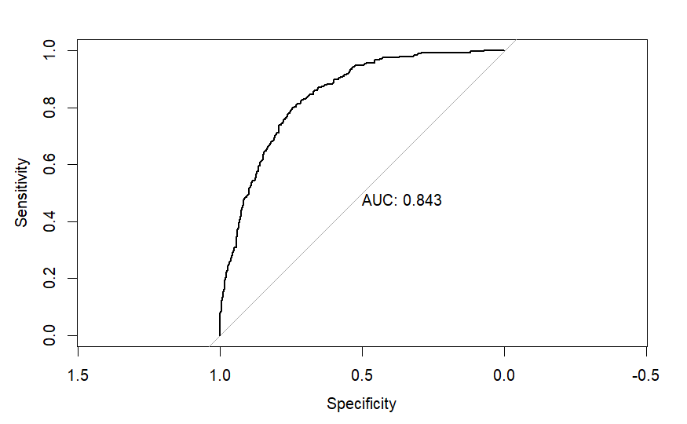

```r
roc(test$Status, extract_pred,plot=TRUE,print.auc=TRUE)
```

##### testing the creation of new models

```r
lda2 <- lda(Status ~ Partner + Dependents + SeniorCitizen + OnlineBackup + Contract + TotalCharges, data = training)
lda2
```

```
Call:
lda(Status ~ Partner + Dependents + SeniorCitizen + OnlineBackup +
    Contract + TotalCharges, data = training)

Prior probabilities of groups:
  Current      Left
0.7308285 0.2691715

Group means:
        PartnerYes DependentsYes SeniorCitizen OnlineBackupNo internet service OnlineBackupYes ContractOne year
Current  0.5262325     0.3469549     0.1270762                      0.27181650       0.3677828       0.24782494
Left     0.3679313     0.1696492     0.2612742                      0.05869721       0.2827487       0.08876163
        ContractTwo year TotalCharges
Current       0.31689955     2546.331
Left          0.02863278     1566.524

Coefficients of linear discriminants:
                                          LD1
PartnerYes                       0.0209699172
DependentsYes                   -0.2716013882
SeniorCitizen                    0.6142891337
OnlineBackupNo internet service -1.3225949475
OnlineBackupYes                 -0.3062365583
ContractOne year                -1.2314241016
ContractTwo year                -1.3563367799
TotalCharges                    -0.0001387557
```

#### Making Predictions (base is 0.5)

```r
lda_pred2 <- predict(lda2,test)
```

##### Extarcing Posterior

```r
extract_pred2 <- lda_pred2[["posterior"]][,2]
```

```r
thresholds <- data.frame(extract_pred2)

# We now add another column and assign classes based on the threshold of 20%. If the posterior is > 0.2 then we assign a "Yes" , else "No".

thresholds <- thresholds %>%
  mutate(Class_th_0.4 = ifelse(extract_pred2 > 0.5, "Left", "Current"), Class_th_0.4 = factor(Class_th_0.4, levels=c("Current","Left")))
```

#### Creating ROC

```
Call:
roc.default(response = test$Status, predictor = thresholds$extract_pred,     plot = TRUE, print.auc = TRUE)

Data: thresholds$extract_pred in 964 controls (test$Status Current) < 334 cases (test$Status Left).
Area under the curve: 0.817
```

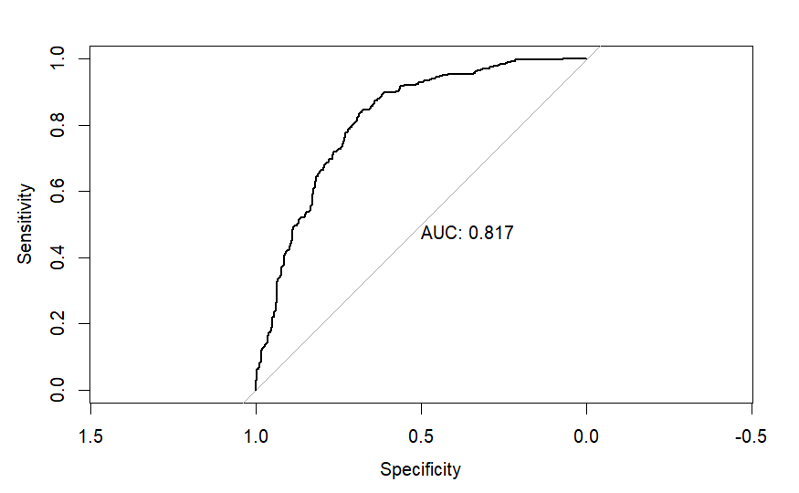

```r
roc(test$Status,thresholds$extract_pred,plot=TRUE,print.auc=TRUE)
```

#### Creating final/best model for LDA

##### testing the creation of new models

```r
lda_f <- lda(Status ~ Contract + InternetService + TotalCharges + Tenure + MonthlyCharges + Dependents + PhoneService + TechSupport + OnlineSecurity + OnlineBackup + MultipleLines + PaperlessBilling, data = training)
lda_f
```

```
Call:
lda(Status ~ Contract + InternetService + TotalCharges + Tenure +
    MonthlyCharges + Dependents + PhoneService + TechSupport +
    OnlineSecurity + OnlineBackup + MultipleLines + PaperlessBilling,
    data = training)

Prior probabilities of groups:
  Current      Left
0.7308285 0.2691715

Group means:
        ContractOne year ContractTwo year InternetServiceFiber optic InternetServiceNo TotalCharges   Tenure
Current       0.24782494       0.31689955                  0.3466913        0.27181650     2546.331 37.33667
Left          0.08876163       0.02863278                  0.7086614        0.05869721     1566.524 18.21188
        MonthlyCharges DependentsYes PhoneServiceYes TechSupportNo internet service TechSupportYes
Current       61.48299     0.3469549       0.9042974                     0.27181650      0.3390456
Left          75.12470     0.1696492       0.9155333                     0.05869721      0.1675018
        OnlineSecurityNo internet service OnlineSecurityYes OnlineBackupNo internet service OnlineBackupYes
Current                        0.27181650         0.3361455                      0.27181650       0.3677828
Left                           0.05869721         0.1603436                      0.05869721       0.2827487
        MultipleLinesNo phone service MultipleLinesYes PaperlessBillingYes
Current                    0.09570261        0.4128658           0.5375692
Left                       0.08446671        0.4581246           0.7480315

Coefficients of linear discriminants:
                                            LD1
ContractOne year                  -0.5893221199
ContractTwo year                  -0.4082462039
InternetServiceFiber optic         0.5296005460
InternetServiceNo                 -0.0677802578
TotalCharges                      -0.0002355905
Tenure                            -0.0084222097
MonthlyCharges                     0.0222910330
DependentsYes                     -0.1518670628
PhoneServiceYes                   -0.3247740048
TechSupportNo internet service    -0.0677802578
TechSupportYes                    -0.4274037201
OnlineSecurityNo internet service -0.0677802578
OnlineSecurityYes                 -0.4224768101
OnlineBackupNo internet service   -0.0677802578
OnlineBackupYes                   -0.2059693671
MultipleLinesNo phone service      0.3247740048
MultipleLinesYes                   0.1587033202
PaperlessBillingYes                0.2545883678
```

#### Making Predictions (base is 0.5)

```r
lda_predf <- predict(lda_f,test)
```

##### Extarcing Posterior

```r
extract_predf <- lda_predf[["posterior"]][,2]
```

```r
thresholds <- data.frame(extract_predf)

# We now add another column and assign classes based on the threshold of 20%. If the posterior is > 0.2 then we assign a "Yes" , else "No".

thresholds <- thresholds %>%
  mutate(Class_th_0.5 = ifelse(extract_predf > 0.5, "Left", "Current"), Class_th_0.5 = factor(Class_th_0.5, levels=c("Current","Left")))
```

#### Creating ROC

```
Call:
roc.default(response = test$Status, predictor = thresholds$extract_pred,     plot = TRUE, print.auc = TRUE)

Data: thresholds$extract_pred in 964 controls (test$Status Current) < 334 cases (test$Status Left).
Area under the curve: 0.8455
```

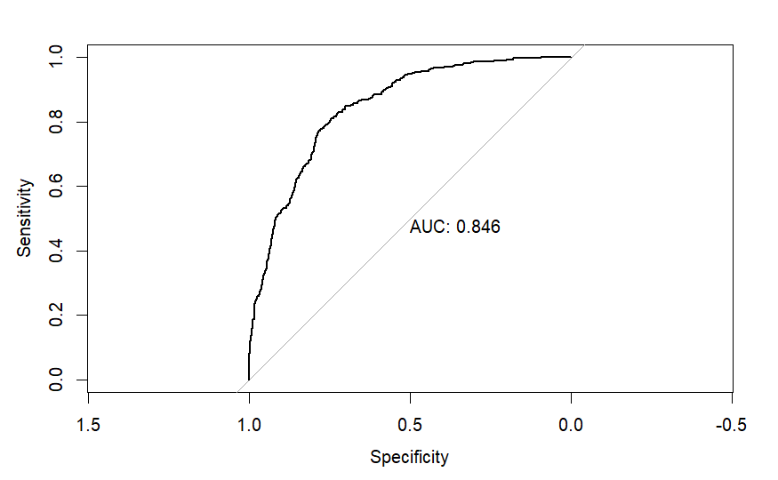

```r
roc(test$Status,thresholds$extract_pred,plot=TRUE,print.auc=TRUE)
```

#### Testing different thresholds in confusion matrices

##### Threshold of 0.5

```r
confusionMatrix(thresholds$Class_th_0.5, test$Status, positive = "Current")
```

```
Confusion Matrix and Statistics

          Reference
Prediction Current Left
   Current     855  156
   Left        109  178

               Accuracy : 0.7958
                 95% CI : (0.7729, 0.8175)
    No Information Rate : 0.7427
    P-Value [Acc > NIR] : 4.236e-06

                  Kappa : 0.4401

 Mcnemar's Test P-Value : 0.004717

            Sensitivity : 0.8869
            Specificity : 0.5329
         Pos Pred Value : 0.8457
         Neg Pred Value : 0.6202
             Prevalence : 0.7427
         Detection Rate : 0.6587
   Detection Prevalence : 0.7789
      Balanced Accuracy : 0.7099

       'Positive' Class : Current
```

##### Threshold of 0.4

```r
thresholds <- data.frame(extract_predf)

# We now add another column and assign classes based on the threshold of 20%. If the posterior is > 0.2 then we assign a "Yes" , else "No".

thresholds <- thresholds %>%
  mutate(Class_th_0.4 = ifelse(extract_predf > 0.4, "Left", "Current"), Class_th_0.4 = factor(Class_th_0.4, levels=c("Current","Left")))
```

```r
confusionMatrix(thresholds$Class_th_0.4, test$Status, positive = "Current")
```

```
Confusion Matrix and Statistics

          Reference
Prediction Current Left
   Current     823  128
   Left        141  206

               Accuracy : 0.7928
                 95% CI : (0.7697, 0.8145)
    No Information Rate : 0.7427
    P-Value [Acc > NIR] : 1.42e-05

                  Kappa : 0.4646

 Mcnemar's Test P-Value : 0.4644

            Sensitivity : 0.8537
            Specificity : 0.6168
         Pos Pred Value : 0.8654
         Neg Pred Value : 0.5937
             Prevalence : 0.7427
         Detection Rate : 0.6341
   Detection Prevalence : 0.7327
      Balanced Accuracy : 0.7353

       'Positive' Class : Current
```

##### Threshold of 0.6

```r
thresholds <- data.frame(extract_predf)

# We now add another column and assign classes based on the threshold of 20%. If the posterior is > 0.2 then we assign a "Yes" , else "No".

thresholds <- thresholds %>%
  mutate(Class_th_0.6 = ifelse(extract_predf > 0.6, "Left", "Current"), Class_th_0.6 = factor(Class_th_0.6, levels=c("Current","Left")))
```

```r
confusionMatrix(thresholds$Class_th_0.6, test$Status, positive = "Current")
```

```
Confusion Matrix and Statistics

          Reference
Prediction Current Left
   Current     893  182
   Left         71  152

               Accuracy : 0.8051
                 95% CI : (0.7825, 0.8263)
    No Information Rate : 0.7427
    P-Value [Acc > NIR] : 7.216e-08

                  Kappa : 0.4279

 Mcnemar's Test P-Value : 4.658e-12

            Sensitivity : 0.9263
            Specificity : 0.4551
         Pos Pred Value : 0.8307
         Neg Pred Value : 0.6816
             Prevalence : 0.7427
         Detection Rate : 0.6880
   Detection Prevalence : 0.8282
      Balanced Accuracy : 0.6907

       'Positive' Class : Current
```

## Part 5 - QDA

## Creating dummy variables for QDA use

```r
 Model_Data2 <- Model_Data %>%
  mutate(Gender_Binary = ifelse(Gender == 'Male', 0, 1),
         Partner_Binary = ifelse(Partner == 'Yes', 0, 1),
         Dependents_Binary = ifelse(Dependents == 'Yes', 0, 1),
         PhoneService_Binary = ifelse(PhoneService == 'Yes', 0, 1),
         PaperlessBilling_Binary = ifelse(PaperlessBilling == 'Yes', 0, 1),
         Status_Binary = ifelse(Status == 'Current', 0, 1))
```

## Extracting just the numeric values

```r
Model_Data_Numeric <- subset(Model_Data2, select = c("SeniorCitizen", "Tenure", "MonthlyCharges", "TotalCharges", "Gender_Binary", "Partner_Binary", "Dependents_Binary", "PhoneService_Binary", "PaperlessBilling_Binary", "Status"))
```

```r
set.seed(2)
q_train <- sample(6488,6488*.8)
q_training <- Model_Data_Numeric[train,]
q_test <- Model_Data_Numeric[-train,]
```

```r
qda <- qda(Status ~., data = q_training)
qda
```

```
Call:
qda(Status ~ ., data = q_training)

Prior probabilities of groups:
  Current      Left
0.7308285 0.2691715

Group means:
        SeniorCitizen   Tenure MonthlyCharges TotalCharges Gender_Binary Partner_Binary Dependents_Binary
Current     0.1270762 37.33667       61.48299     2546.331     0.4945953      0.4737675         0.6530451
Left        0.2612742 18.21188       75.12470     1566.524     0.5125268      0.6320687         0.8303508
        PhoneService_Binary PaperlessBilling_Binary
Current          0.09570261               0.4624308
Left             0.08446671               0.2519685
```

#### Making Predictions (base is 0.5)

```r
qda_pred <- predict(qda,q_test)
```

##### Extarcing Posterior

```r
extract_pred <- qda_pred[["posterior"]][,2]
```

#### Creating ROC

```
Call:
roc.default(response = q_test$Status, predictor = extract_pred,     plot = TRUE, print.auc = TRUE)

Data: extract_pred in 964 controls (q_test$Status Current) < 334 cases (q_test$Status Left).
Area under the curve: 0.8117
```

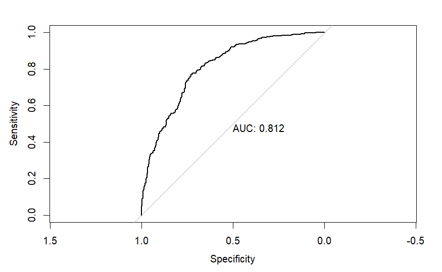

```r
roc(q_test$Status, extract_pred,plot=TRUE,print.auc=TRUE)
```

##### testing the creation of new models

```r
qda2 <- qda(Status ~ Tenure + Partner_Binary + SeniorCitizen, data = q_training)
qda2
```

```
Call:
qda(Status ~ Tenure + Partner_Binary + SeniorCitizen, data = q_training)

Prior probabilities of groups:
  Current      Left
0.7308285 0.2691715

Group means:
          Tenure Partner_Binary SeniorCitizen
Current 37.33667      0.4737675     0.1270762
Left    18.21188      0.6320687     0.2612742
```

#### Making Predictions (base is 0.5)

```r
qda_pred2 <- predict(qda2,q_test)
```

##### Extarcing Posterior

```r
extract_pred2 <- qda_pred2[["posterior"]][,2]
```

#### Creating ROC

```
Call:
roc.default(response = q_test$Status, predictor = extract_pred2,     plot = TRUE, print.auc = TRUE)

Data: extract_pred2 in 964 controls (q_test$Status Current) < 334 cases (q_test$Status Left).
Area under the curve: 0.7719
```

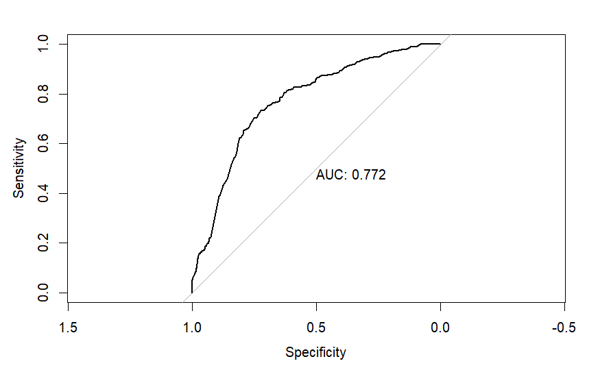

```r
roc(q_test$Status, extract_pred2,plot=TRUE,print.auc=TRUE)
```

##### testing the creation of final model

```r
qda3 <- qda(Status ~ Tenure + Dependents_Binary + TotalCharges + MonthlyCharges + PhoneService_Binary, data = q_training)
qda3
```

```
Call:
qda(Status ~ Tenure + Dependents_Binary + TotalCharges + MonthlyCharges +
    PhoneService_Binary, data = q_training)

Prior probabilities of groups:
  Current      Left
0.7308285 0.2691715

Group means:
          Tenure Dependents_Binary TotalCharges MonthlyCharges PhoneService_Binary
Current 37.33667         0.6530451     2546.331       61.48299          0.09570261
Left    18.21188         0.8303508     1566.524       75.12470          0.08446671
```

#### Making Predictions (base is 0.5)

```r
qda_pred3 <- predict(qda3,q_test)
```

##### Extarcing Posterior

```r
extract_pred3 <- qda_pred3[["posterior"]][,2]
```

#### Creating ROC

```
Call:
roc.default(response = q_test$Status, predictor = extract_pred3,     plot = TRUE, print.auc = TRUE)

Data: extract_pred3 in 964 controls (q_test$Status Current) < 334 cases (q_test$Status Left).
Area under the curve: 0.8144
```

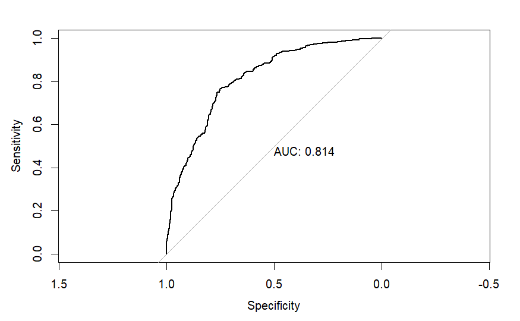

```r
roc(q_test$Status, extract_pred3,plot=TRUE,print.auc=TRUE)
```

#### Creating different thresholds to test - starting with 0.5

```r
thresholds <- data.frame(extract_pred3)

# We now add another column and assign classes based on the threshold of 20%. If the posterior is > 0.2 then we assign a "Yes" , else "No".

thresholds <- thresholds %>%
  mutate(Class_th_0.5 = ifelse(extract_pred3 > 0.5, "Left", "Current"), Class_th_0.5 = factor(Class_th_0.5, levels=c("Current","Left")))
```

```r
confusionMatrix(thresholds$Class_th_0.5, q_test$Status, positive = "Current")
```

```
Confusion Matrix and Statistics

          Reference
Prediction Current Left
   Current     759  105
   Left        205  229

               Accuracy : 0.7612
                 95% CI : (0.737, 0.7841)
    No Information Rate : 0.7427
    P-Value [Acc > NIR] : 0.06698

                  Kappa : 0.4308

 Mcnemar's Test P-Value : 1.879e-08

            Sensitivity : 0.7873
            Specificity : 0.6856
         Pos Pred Value : 0.8785
         Neg Pred Value : 0.5276
             Prevalence : 0.7427
         Detection Rate : 0.5847
   Detection Prevalence : 0.6656
      Balanced Accuracy : 0.7365

       'Positive' Class : Current
```

#### Testing threshold at 0.4

```r
thresholds <- data.frame(extract_pred3)

# We now add another column and assign classes based on the threshold of 20%. If the posterior is > 0.2 then we assign a "Yes" , else "No".

thresholds <- thresholds %>%
  mutate(Class_th_0.4 = ifelse(extract_pred3 > 0.4, "Left", "Current"), Class_th_0.4 = factor(Class_th_0.4, levels=c("Current","Left")))
```

```r
confusionMatrix(thresholds$Class_th_0.4, q_test$Status, positive = "Current")
```

```
Confusion Matrix and Statistics

          Reference
Prediction Current Left
   Current     726   83
   Left        238  251

               Accuracy : 0.7527
                 95% CI : (0.7283, 0.776)
    No Information Rate : 0.7427
    P-Value [Acc > NIR] : 0.2143

                  Kappa : 0.4382

 Mcnemar's Test P-Value : <2e-16

            Sensitivity : 0.7531
            Specificity : 0.7515
         Pos Pred Value : 0.8974
         Neg Pred Value : 0.5133
             Prevalence : 0.7427
         Detection Rate : 0.5593
   Detection Prevalence : 0.6233
      Balanced Accuracy : 0.7523

       'Positive' Class : Current
```

#### Testing for threshold of 0.6

```r
thresholds <- data.frame(extract_pred3)

# We now add another column and assign classes based on the threshold of 20%. If the posterior is > 0.2 then we assign a "Yes" , else "No".

thresholds <- thresholds %>%
  mutate(Class_th_0.6 = ifelse(extract_pred3 > 0.6, "Left", "Current"), Class_th_0.6 = factor(Class_th_0.6, levels=c("Current","Left")))
```

```r
confusionMatrix(thresholds$Class_th_0.6, test$Status, positive = "Current")
```

```
Confusion Matrix and Statistics

          Reference
Prediction Current Left
   Current     805  149
   Left        159  185

               Accuracy : 0.7627
                 95% CI : (0.7386, 0.7856)
    No Information Rate : 0.7427
    P-Value [Acc > NIR] : 0.05178

                  Kappa : 0.3852

 Mcnemar's Test P-Value : 0.60808

            Sensitivity : 0.8351
            Specificity : 0.5539
         Pos Pred Value : 0.8438
         Neg Pred Value : 0.5378
             Prevalence : 0.7427
         Detection Rate : 0.6202
   Detection Prevalence : 0.7350
      Balanced Accuracy : 0.6945

       'Positive' Class : Current
```

## Part 6 - Decision Trees

#### Creating a classification tree

```r
tree.status <- tree(Status ~.,training)
```

#### Plotting the tree

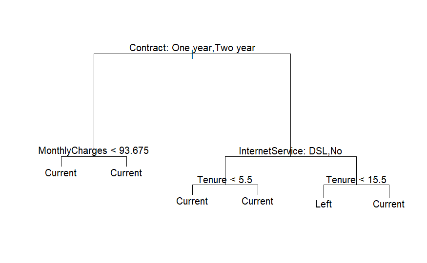

```r
plot(tree.status)
text(tree.status, pretty = 0)
```

#### Making predictions

```r
tree.pred.test <- predict(tree.status, test, type = "class")
```

```r
table(tree.pred.test, test$Status)
```

```
tree.pred.test Current Left
       Current     906  211
       Left         58  123
```

#### Calculating the accuracy

```r
(906+123)/(1298)*100
```

```
[1] 79.27581
```

#### Creating a new model with bagging to look for importance

```r
bag.status <- randomForest(Status ~., data = training, mtry = 13, importance = TRUE)
```

```r
importance(bag.status)
```

```
                   Current       Left MeanDecreaseAccuracy MeanDecreaseGini
Gender            1.330658  1.0717729             1.703287        45.862207
SeniorCitizen    17.021381  0.4225942            14.905211        44.614823
Partner           9.938956 -0.4424156             7.948382        36.279806
Dependents       -4.936926 11.2786439             3.487345        32.030217
Tenure           25.626524 18.7933003            42.195736       259.733674
PhoneService      1.526340  4.9967119             4.581591         3.992891
MultipleLines     8.103527  6.0647547            10.454455        34.198034
InternetService  12.186511 24.5243787            28.352497        85.750854
OnlineSecurity   21.898185 21.4056245            26.822484        82.268805
OnlineBackup      9.318876 16.6911366            17.669795        35.580526
DeviceProtection 10.261624 -2.1270411             9.398532        27.782061
TechSupport       6.988045 35.0428202            21.365289        62.281982
StreamingTV       9.431921 -1.9002795             8.965255        20.925372
StreamingMovies  12.564401 -1.5044487            11.923686        24.426251
Contract         -5.060483 48.4413058            45.692803       262.311729
PaperlessBilling -4.023094 20.3467369            12.154248        43.934252
PaymentMethod    -0.147483 22.8193470            14.997429       105.253892
MonthlyCharges   29.953301 17.7137367            40.452964       407.685252
TotalCharges     31.548109 17.1473958            43.466461       417.460826
```

#### Plotting it

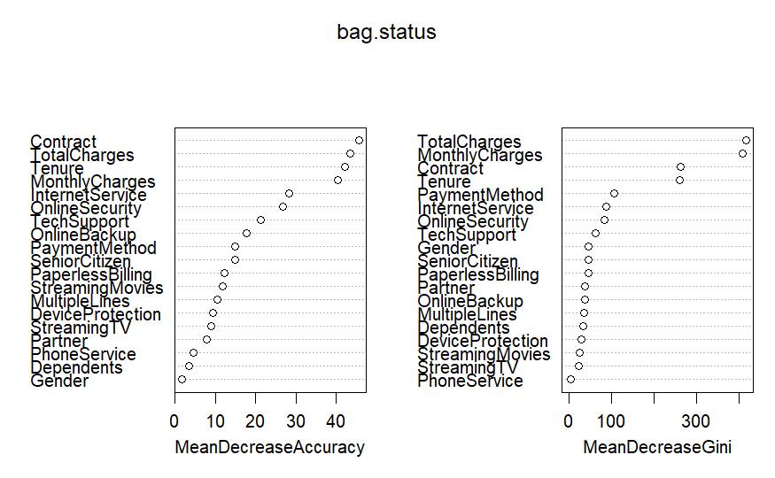

```r
varImpPlot(bag.status)
```

- It looks like are most important factors are Contract, Total Charges, Tenure, and Monthly Charges

#### Creating a model based on the importanc factors

```r
tree.status2 <- tree(Status ~ Contract + TotalCharges + Tenure + MonthlyCharges,training)
```

#### Plotting the tree

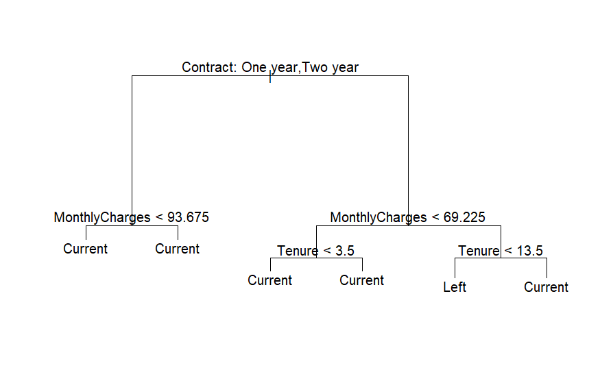

```r
plot(tree.status2)
text(tree.status2, pretty = 0)
```

#### Making predictions

```r
tree.pred.test2 <- predict(tree.status2, test, type = "class")
```

#### Testing accuracy

```r
table(tree.pred.test2, test$Status)
```

```
tree.pred.test2 Current Left
        Current     908  221
        Left         56  113
```

```r
(908+113)/1298*100
```

```
[1] 78.65948
```

- This accuracy is actually worse than the base model we created which is a little surprising since these are the most important predictors

#### Random Forest

```r
forest.status <- randomForest(Status ~., data = training, importance = TRUE)
```

```r
importance(forest.status)
```

```
                    Current        Left MeanDecreaseAccuracy MeanDecreaseGini
Gender            0.5730195  1.34876327             1.339379        45.878995
SeniorCitizen    11.7272644  2.39138806            11.466795        40.777770
Partner           8.1796080  0.08472372             7.041476        38.459095
Dependents       -3.1095102 10.93273979             5.322706        33.700774
Tenure           26.7386724 25.27098993            44.573621       280.376029
PhoneService      3.2700780  5.93832075             7.024710         7.416537
MultipleLines     1.8960107  8.41303546             7.571194        42.151497
InternetService  17.3690453 22.28149116            25.505872        79.981535
OnlineSecurity   11.5724523 25.12948691            20.347105        85.654413
OnlineBackup      9.0295780 12.18308203            13.655650        48.804790
DeviceProtection  8.9134974  0.01136838             8.961672        39.539079
TechSupport       8.3406345 29.58614945            19.059951        79.007568
StreamingTV       7.3060596  3.31650959             8.254667        36.861011
StreamingMovies   9.6591637  2.31586137            10.348778        36.208291
Contract         -2.8399693 32.86531273            33.903077       141.531868
PaperlessBilling -1.8115620 20.97724856            13.712995        45.036328
PaymentMethod     2.2226885 20.50863601            15.566184       124.119344
MonthlyCharges   21.6064072 18.80466472            33.393200       294.702117
TotalCharges     27.7943195 17.51282522            40.831970       319.798170
```

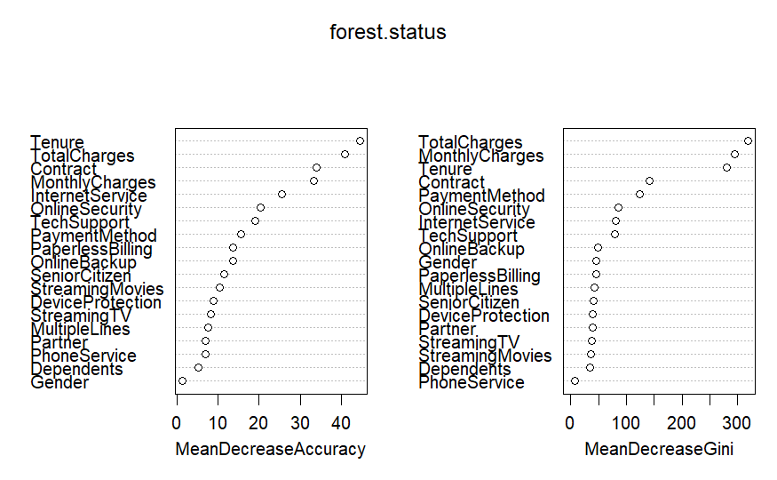

```r
varImpPlot(forest.status)
```

- More of less has the same top predictors

#### Making one last model

```r
tree.status3 <- tree(Status ~ Contract + TotalCharges + Tenure + MonthlyCharges + InternetService, training)
```

#### Plotting the tree

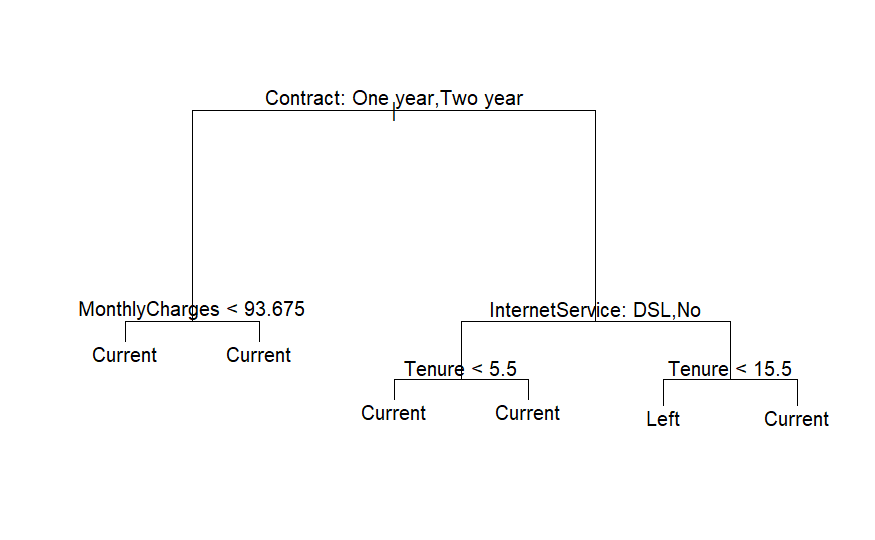

```r
plot(tree.status3)
text(tree.status3, pretty = 0)
```

#### Making predictions

```r
tree.pred.test3 <- predict(tree.status3, test, type = "class")
```

#### Testing accuracy

```r
table(tree.pred.test3, test$Status)
```

```
tree.pred.test3 Current Left
        Current     906  211
        Left         58  123
```

```r
(906+123)/(1298)*100
```

```
[1] 79.27581
```

- This model looks to be the same as the ‘base’ model that was calculated perhaps meaning R automatically selected this as the most accurate model?

## Part 7 - Comparison across Methods

**Method with best ROC:** The method with the best ROC was the Logistic Regression model with an AUC of .861 **Best Accuracy:* The model with the best accuracy was this same logistic regression model with an accuracy if 80.89 closely followed by the LDA model at a 0.6 threshold with a 80.51% accuracy.

## Part 8 - Business Analysis and Recommendations

#### Loading Implementation data

```r
load('Implementation_Data.rda')
```

#### Creating Train and Testing Sets

```r
set.seed(2)
i_train <- sample(500,500*.8)
i_training <- Implementation_Data[i_train,]
i_test <- Implementation_Data[-train,]
```

#### Building model

##### Creating cubed variables

```r
Implementation_Data <- Implementation_Data %>%
  mutate(Tenure_Sqr = Tenure^2) %>%
  mutate(TotalCharges_Sqr = TotalCharges^3) %>%
  mutate(MonthlyCharges_Sqr = MonthlyCharges^3)
```

##### Predictions model

```r
Predictions_Probabilities3 <- predict(LogisticModel.train3, type = "response", newdata = Implementation_Data)
```

#### Creating different thresholds to test - starting with 0.5

```r
thresholds <- data.frame(Predictions_Probabilities3)

# We now add another column and assign classes based on the threshold of 20%. If the posterior is > 0.2 then we assign a "Yes" , else "No".

thresholds <- thresholds %>%
  mutate(Class_th_0.5 = ifelse(Predictions_Probabilities3 > 0.5, "Left", "Current"), Class_th_0.5 = factor(Class_th_0.5, levels=c("Current","Left")))
```

#### Showing results

```r
table(thresholds$Class_th_0.5)
```

```
Current    Left
    390     110
```

#### Anlysis and Business Decision

In terms of importance factors the top 5 factors are Tenure, Contract, Monthly and Total Charges, and Internet Service (not listed in order… view chart at line 871 for further listings)

**Predictions:** We are predicted to lose 110 customers. This is 22% of our customers.Which is a 22% hit to our revenue.

```r
.22*sum(Implementation_Data$MonthlyCharges)
```

```
[1] 7254.324
```

```r
mean(Implementation_Data$MonthlyCharges)
```

```
[1] 65.9484
```

There would be about a $7254.32 hit to monthly revenues if we lost these customers.

As a Business Manager I would focus on investing more in incentive programs to streaming TV and movies as well as creating a bundling option for our customers to get services like Tech Support, Online Backups and Security, and Device Protection. I believe creating an incentive based program that allows for a reduction in monthly charges could be useful since month-to-month payers are our highest ‘leaving’ group. Being able to reduce those charges would allow us to retain more customers. I also believe bundling TV and Movies would give customers a reason to make the purchase and more incentive to stay under our service since we are providing them a two-in-one service. The company should also push for customers to sign into 1 or 2 year contracts instead of month-to-month

Based on my planning above I would first start with allowing customers a reduction in monthly rates by 8% if they join the 1-year contract from a month-to-month and 12% rates for switching to a two year plan for month-to-month. If users are already one one of these plans we will give them the same 4% increase in monthly charges off if they go from 1-year to 2-year and if they’re already 2-year contracts we will give them 2 months free of charge on their next billing cycle. Fees will go back to normal after trial

Next, we will offer all customers a chance to bundle Tech Support, Online Backups and Security, and Device Protection all together at a pro-rated fee. This will be just about 10% lower than if you were to sum each price together. This is open to all customers and if you already have all four you have to opt into this program once your fee is done.

Lastly we will do a movies and tv bundle that allows customers to purchase both for a 10% discounted rate of the total costs to both (lets say its 10 + 8 a month, it would now be ~2$ off when switching to this bundle - must sign for a 1yr contract)

My case is that we take minor monthly charge loss from providing discounts but we can retain many more customers by offering various bundles. Alone our value from maintaining just 50% of those customer leaving if they opt in for the cheapest bundle option (the movie and tv bundle) will profit us extra 880$ a month.

The average customer spends around $66 a month with our service. An by our incentives reducing their costs just slightly we can maintaining more customers while still profiting.

For the contracting incentive you are locking in year long contracts and reducing your leaving rate from month-to-month customers this could provide a vast increase in monthly revenues when securing these customers on a yearly basis. You lock down another year of payments. For customers who sign yearly contracts back to back we can send them gift cards or set up a program (for every 5yrs you get 6 months free, 10years you get a full year for free) This will provide guaranteed profits to the future worth over 42,900 $ in base profits from this incentive program just on an annual basis if just 50% of those wanting to leave stay. since customers are signing onto these programs and locking in to either a full year or two years which would present even more monetary value.

With the introduction of incentive programs it is a no brainier when it comes to implementation because it increase customer retention exponentially and will provide customers extra reasons to stay on our service with an abundance of incentives and offers going around. Through the incentives program we can guarantee customers for at least a year when they sign up and from there push other new product and services through trails that are tied in within the incentives program. We’re looking at increased customer retention and satifaction that would lead to higher monthly and annual revenues with less and less customers dropping/leaving our services due to a decrease in the amount of month-to-month contracts signed.